# Section 9: Structural Equation Modeling (SEM) Continued

Load in some packages

```r
library(ggplot2)
theme_set(theme_bw(base_size = 18))
library(lavaan)
library(semPlot)
library(corrplot)

plot_matrix <- function(matrix_toplot){
corrplot(matrix_toplot, is.corr = FALSE,
               type = 'lower',
               order = "original",
               tl.col='black', tl.cex=.75)
}
```

## Recap of lavaan models

Similar to `lm()` and `lmer()`, etc., the model format has the DV on the left side of the operator, and the IV on the right side. In terms of the structural diagram, you could think of the arrow going from right to left. When the operator is a `~` this is regression, such that the DV(s) are “predicted by” the IV(s). When the operator is `=~` we are defining a latent variable, reading it like L is “measured by” IVs. Variances/covariances are specified with a `~~` (e.g., DV is “correlated with” DV), and intercepts are simple regression formulas with `1` as the predictor. We include all these formulas inside **single quotes**.

- **Regressions**
  - Y is predicted by X1 and X2: `Y ~ X1 + X2`
  - Y1 is predicted by X1, and Y2 is predicted by X1: `Y1 + Y2 ~ X1`
- **Latent Variables**
  - Latent variable L is measured by variables U and V: `L =~ U + V`
- **Variances & covariances**
  - The variance of X: `X ~~ X`
  - The covariance of X and Y1: `X ~~ Y1`
  - The covariance of X and Y2 is fixed at 0: `X ~~ 0*Y2`
- **Intercepts**
  - The intercept of X: `X ~ 1`

For some practice generating the structural plot and equations, go [here](http://www.stanford.edu/class/psych253/section/section_8/example_lavaan.html)!

## Question B: Adding regression coefficients

Here, Sadler & Woody (2003) test an interpersonal theory of dyadic interaction: Person M’s ‘behavior’ when interacting with person F (i.e., M’s situational behavior) is influenced by (i) M’s long-term tendency to elicit the behavior (i.e., M’s behavioral trait), and (ii) F’s situational behavior. The same is assumed true for F.

The four variables, trait and behavior for each of M and F, are represented as **latent variables** that can be measured in multiple ways. “Reciprocal influence” is conceptualized as M’s situational behavior influencing F’s situational behavior, and vice versa. In this study, M and F were strangers, so M’s trait (which is unknown to F) couldn’t affect F’s situational behavior. However, if M and F were friends, such links would be expected to be significant and should be included in the model. Trait is measured by self-report and a friend’s report; and situational behavior is rated by self, partner and an observer. Rater biases are introduced through the use of covariance arrows.

### Variable coding:

1. Female or male (M/F)
2. Situational or trait (S/T)
3. Observer, partner, friend, or self rating (O/I/F/S)
4. Rating (R)

### Load in data

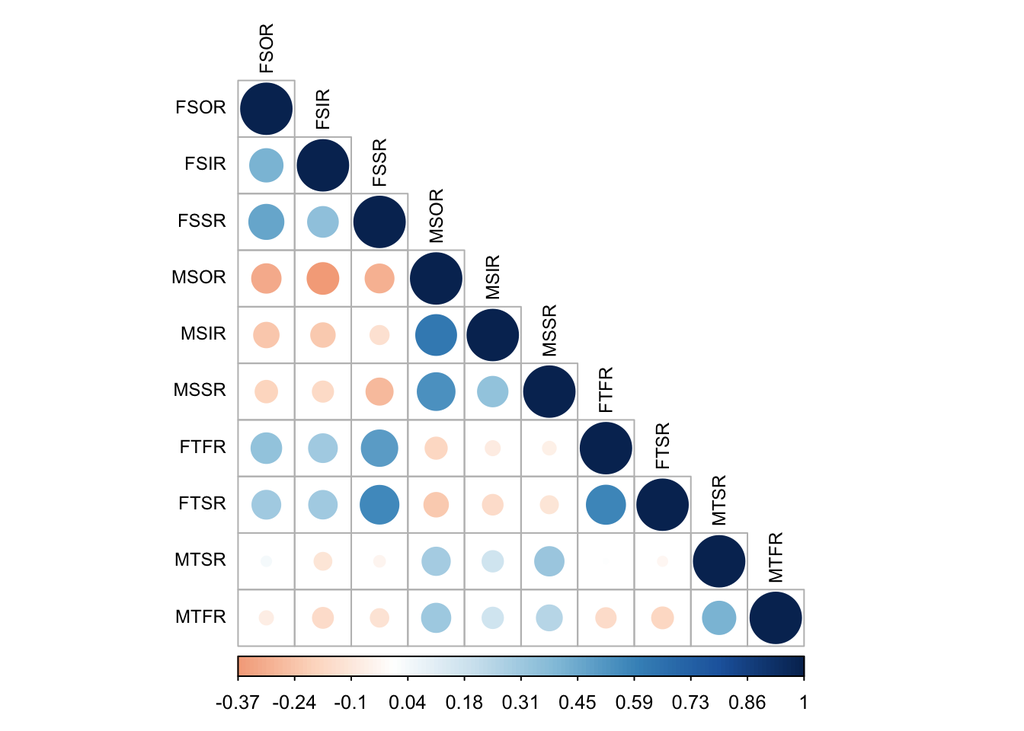

```r
low.dom = '
1
.415 1
.460 .351 1
-.321 -.374 -.310 1
-.239 -.221 -.133 .626 1
-.185 -.164 -.272 .533 .345 1
.349 .307 .496 -.180 -.081 -.067 1
.308 .302 .562 -.222 -.156 -.118 .573 1
.038 -.115 -.048 .296 .167 .320 .008 -.036 1
-.072 -.160 -.124 .317 .167 .248 -.152 -.175 .414 1
'

labels1 = c("FSOR", "FSIR", "FSSR", "MSOR", "MSIR", "MSSR", "FTFR", "FTSR", "MTSR", "MTFR")
dom.cov = getCov(low.dom, names = labels1)
plot_matrix(dom.cov)
```

### Segue about directionality!

```r
dyad.ex1 = '
  FSSR ~ FTSR
'
dyad.ex2 = '
  FTSR ~ FSSR
'

dyad.fit_ex1 = sem(dyad.ex1, fixed.x = F, sample.cov = dom.cov, sample.nobs = 112)
```

```
## Found more than one class "Model" in cache; using the first, from namespace 'lavaan'
```

```r
# parameterEstimates(dyad.fit_ex1)

dyad.fit_ex2 = sem(dyad.ex2, fixed.x = F, sample.cov = dom.cov, sample.nobs = 112)
# parameterEstimates(dyad.fit_ex2)

anova(dyad.fit_ex1, dyad.fit_ex2)
```

```
## Chi Square Difference Test
##
##              Df    AIC    BIC Chisq Chisq diff Df diff Pr(>Chisq)
## dyad.fit_ex1  0 597.16 605.32     0
## dyad.fit_ex2  0 597.16 605.32     0          0       0          1
```

```r
dyad.ex1 = '
  FSSR ~ FTSR
  FSSR ~ MSSR
'
dyad.ex2 = '
  FTSR ~ FSSR
  FSSR ~ MSSR
'

dyad.fit_ex1 = sem(dyad.ex1, fixed.x = F, sample.cov = dom.cov, sample.nobs = 112)
# parameterEstimates(dyad.fit_ex1)

dyad.fit_ex2 = sem(dyad.ex2, fixed.x = F, sample.cov = dom.cov, sample.nobs = 112)
# parameterEstimates(dyad.fit_ex2)

anova(dyad.fit_ex1, dyad.fit_ex2)
```

```
## Chi Square Difference Test
##
##              Df    AIC    BIC  Chisq Chisq diff Df diff Pr(>Chisq)
## dyad.fit_ex1  0 911.18 927.49 0.0000
## dyad.fit_ex2  1 909.39 922.99 0.2151    0.21509       1     0.6428
```

Here, the estimates have changed slightly, but also note the addition of a covariance between `FTSR ~~ MSSR` into the first model! The variance estimates have also changed slightly.

### Unconstrained paths

Here, we have latent variables that are measured by observed variables. Specifically, female trait dominance (FTZ) is measured by friends and self trait ratings (FTSR and FTFT). Similarly, female situational dominance (FSZ) is measured by self, partner, and observers’ ratings. The same is true for males. Thus, we’ll have to define these latent variables in the model, and then see how these latent variables are predicted by other latent variables!

We want to estimate the paths A and B (the effect of the individuals’ traits on their situational behavior) and C and D (the effects of individuals’ situational behavior on each other). Let’s first allow these paths to be unconstrained (i.e., we can get a different estimate for each path).

Using the `*` operator below “names” the regression coefficient. This is useful mainly because if we give to coefficients the same name, the function automatically constrains them to be the same.

```r
dyad.model1 = '
  # Latent variable definitions for trait, FTZ & MTZ, and situation, FSZ & MSZ
    FTZ =~ FTSR + FTFR
    MTZ =~ MTSR + MTFR
    FSZ =~ FSSR + FSIR + FSOR
    MSZ =~ MSSR + MSIR + MSOR

    # regressions
    FSZ ~ B*FTZ + C*MSZ
    MSZ ~ A*MTZ + D*FSZ

    # variances and covariances
    # Residual correls among M ratings, MTSR, MSSR, FSIR
    MTSR + MSSR ~~ FSIR
    MSSR ~~ MTSR

    # Residual correls among F ratings, FTSR, FSSR, MSIR
    FTSR + FSSR ~~ MSIR
    FSSR ~~ FTSR

    # Residual correls among Observer situational ratings, MSOR, FSOR
    MSOR ~~ FSOR
'
```

```r
dyad.fit1 = sem(dyad.model1, fixed.x = F, sample.cov = dom.cov, sample.nobs = 112)
print(dyad.fit1) #good p value
```

```
## lavaan (0.5-20) converged normally after  41 iterations
##
##   Number of observations                           112
##
##   Estimator                                         ML
##   Minimum Function Test Statistic               17.306
##   Degrees of freedom                                23
##   P-value (Chi-square)                           0.794
```

```r
summary(dyad.fit1, fit.measures = TRUE)
```

```
## lavaan (0.5-20) converged normally after  41 iterations
##
##   Number of observations                           112
##
##   Estimator                                         ML
##   Minimum Function Test Statistic               17.306
##   Degrees of freedom                                23
##   P-value (Chi-square)                           0.794
##
## Model test baseline model:
##
##   Minimum Function Test Statistic              324.587
##   Degrees of freedom                                45
##   P-value                                        0.000
##
## User model versus baseline model:
##
##   Comparative Fit Index (CFI)                    1.000
##   Tucker-Lewis Index (TLI)                       1.040
##
## Loglikelihood and Information Criteria:
##
##   Loglikelihood user model (H0)              -1430.548
##   Loglikelihood unrestricted model (H1)      -1421.895
##
##   Number of free parameters                         32
##   Akaike (AIC)                                2925.096
##   Bayesian (BIC)                              3012.088
##   Sample-size adjusted Bayesian (BIC)         2910.957
##
## Root Mean Square Error of Approximation:
##
##   RMSEA                                          0.000
##   90 Percent Confidence Interval          0.000  0.052
##   P-value RMSEA <= 0.05                          0.944
##
## Standardized Root Mean Square Residual:
##
##   SRMR                                           0.043
##
```

[output cut: 51 more lines]

```
##                    Estimate  Std.Err  Z-value  P(>|z|)
##     FTSR              0.485    0.111    4.380    0.000
##     FTFR              0.375    0.124    3.025    0.002
##     MTSR              0.629    0.142    4.422    0.000
##     MTFR              0.545    0.163    3.342    0.001
##     FSSR              0.498    0.098    5.070    0.000
##     FSIR              0.661    0.105    6.291    0.000
##     FSOR              0.571    0.101    5.665    0.000
##     MSSR              0.677    0.099    6.842    0.000
##     MSIR              0.571    0.091    6.280    0.000
##     MSOR              0.088    0.106    0.837    0.403
##     FTZ               0.491    0.143    3.419    0.001
##     MTZ               0.350    0.152    2.310    0.021
##     FSZ               0.158    0.073    2.167    0.030
##     MSZ               0.189    0.065    2.920    0.004
```

```r
parameterEstimates(dyad.fit1) #good p value
```

```
##     lhs op  rhs label    est    se      z pvalue ci.lower ci.upper
## 1   FTZ =~ FTSR        1.000 0.000     NA     NA    1.000    1.000
## 2   FTZ =~ FTFR        1.120 0.231  4.858  0.000    0.668    1.573
## 3   MTZ =~ MTSR        1.000 0.000     NA     NA    1.000    1.000
## 4   MTZ =~ MTFR        1.129 0.382  2.952  0.003    0.380    1.879
## 5   FSZ =~ FSSR        1.000 0.000     NA     NA    1.000    1.000
## 6   FSZ =~ FSIR        0.833 0.167  4.984  0.000    0.505    1.160
## 7   FSZ =~ FSOR        0.928 0.175  5.297  0.000    0.585    1.271
## 8   MSZ =~ MSSR        1.000 0.000     NA     NA    1.000    1.000
## 9   MSZ =~ MSIR        1.127 0.207  5.435  0.000    0.721    1.534
## 10  MSZ =~ MSOR        1.678 0.302  5.563  0.000    1.087    2.269
## 11  FSZ  ~  FTZ     B  0.696 0.136  5.116  0.000    0.430    0.963
## 12  FSZ  ~  MSZ     C -0.283 0.160 -1.769  0.077   -0.597    0.031
## 13  MSZ  ~  MTZ     A  0.418 0.152  2.741  0.006    0.119    0.716
## 14  MSZ  ~  FSZ     D -0.231 0.115 -2.008  0.045   -0.457   -0.006
```

[output cut: 22 more lines]

Note that for each latent variable, the path from the latent variable to one of its indicator variables is assigned the value of 1.0! By default this is the first variable specified in the `{lavaan}` model. Given this constraint, the remaining paths (i.e., the paths from the latent variable to the other indicators) can then be estimated. The indicator selected to be constrained to 1.0 is the **reference item**. Typically one selects as the reference item the one which in factor analysis loads most heavily on the dimension represented by the latent variable, thereby allowing it to anchor the meaning of that dimension.

#### Visualize the standardized paths

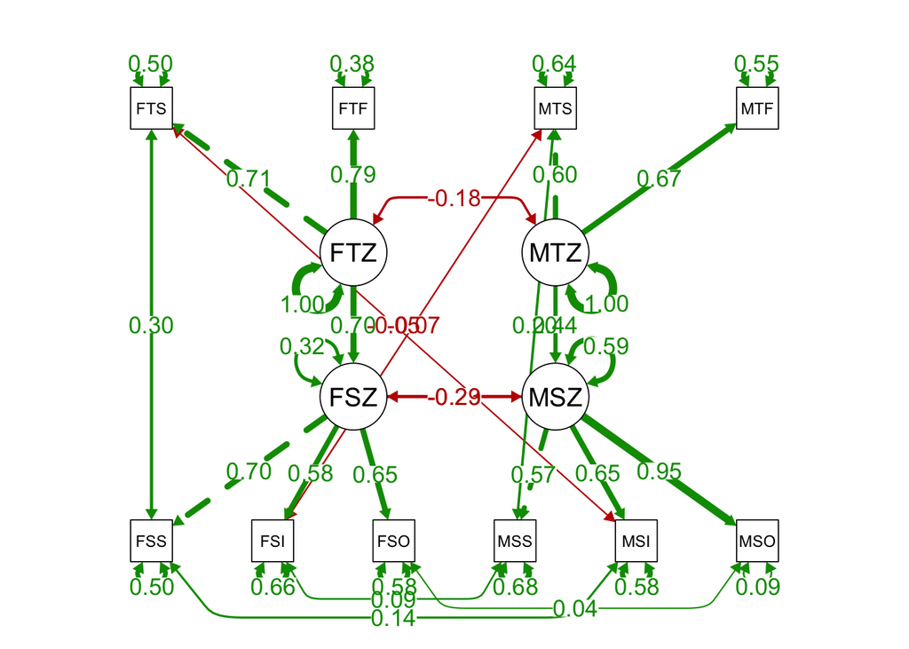

```r
semPaths(dyad.fit1, what='std',
         node.label.cex=5,
         edge.label.cex=1.25, curvePivot = TRUE,
         fade=FALSE)
```

Note that the semPaths function here is showing the standardized parameter estimates – we can get those here:

```r
standardizedSolution(dyad.fit1)
```

```
##     lhs op  rhs est.std    se      z pvalue
## 1   FTZ =~ FTSR   0.709 0.080  8.895  0.000
## 2   FTZ =~ FTFR   0.788 0.081  9.741  0.000
## 3   MTZ =~ MTSR   0.598 0.115  5.208  0.000
## 4   MTZ =~ MTFR   0.671 0.121  5.537  0.000
## 5   FSZ =~ FSSR   0.704 0.070  9.998  0.000
## 6   FSZ =~ FSIR   0.583 0.079  7.375  0.000
## 7   FSZ =~ FSOR   0.652 0.074  8.753  0.000
## 8   MSZ =~ MSSR   0.568 0.073  7.766  0.000
## 9   MSZ =~ MSIR   0.646 0.068  9.569  0.000
## 10  MSZ =~ MSOR   0.955 0.056 17.094  0.000
## 11  FSZ  ~  FTZ   0.697 0.088  7.930  0.000
## 12  FSZ  ~  MSZ  -0.230 0.128 -1.790  0.073
## 13  MSZ  ~  MTZ   0.435 0.110  3.976  0.000
## 14  MSZ  ~  FSZ  -0.285 0.132 -2.154  0.031
```

[output cut: 22 more lines]

These parameter estimates are **standardized**, basically meaning that the **factor variances are set to 1**. Here, you can see that the path from the latent variable to the one of its indicator variables that *had* been assigned the value of 1.0 above (i.e., in the unstandardized solution) is no longer 1.0! In ho-5-SEM2.pdf Ewart notes that “**cross-group comparisons of standardized path coefficients** are **NOT recommended** as this confounds differences in strength of relationship with differences in the ratio of independent to dependent variable variances”!

#### Assess model

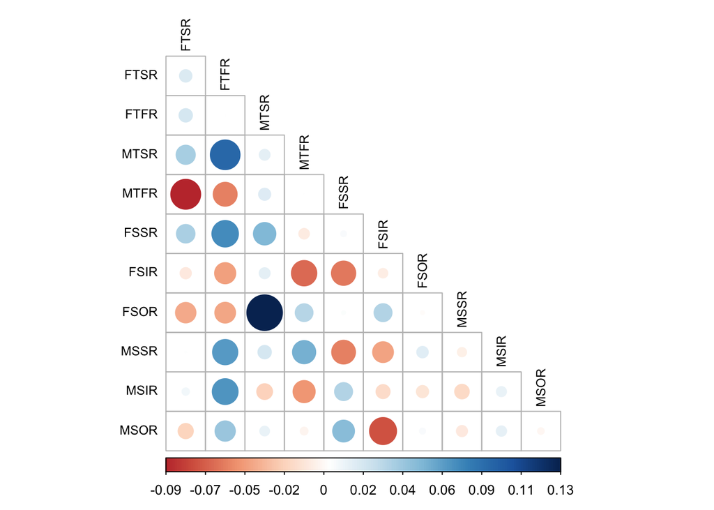

```r
plot_matrix(residuals(dyad.fit1)$cov)
```

```r
mi = modificationIndices(dyad.fit1)
head(mi[order(-mi$mi), ], 10)
```

```
##     lhs op  rhs    mi    epc sepc.lv sepc.all sepc.nox
## 76 FTFR ~~ FSSR 5.296  0.213   0.213    0.215    0.215
## 39  FTZ =~ FSSR 5.261  0.809   0.567    0.570    0.570
## 96 FSSR ~~ MSOR 3.396  0.134   0.134    0.135    0.135
## 38  FTZ =~ MTFR 3.023 -0.333  -0.234   -0.235   -0.235
## 55  FSZ =~ MTSR 2.768  0.328   0.229    0.232    0.232
## 93 FSSR ~~ FSIR 2.764 -0.136  -0.136   -0.137   -0.137
## 37  FTZ =~ MTSR 2.435  0.265   0.186    0.188    0.188
## 95 FSSR ~~ MSSR 2.394 -0.097  -0.097   -0.098   -0.098
## 65  MSZ =~ FSIR 2.276 -0.327  -0.186   -0.186   -0.186
## 99 FSIR ~~ MSOR 1.998 -0.096  -0.096   -0.096   -0.096
```

This model is ok, but let’s see if we can get a simpler model that works! Let’s try taking out most of the covariance terms.

```r
dyad.model2 = '
  # Latent variable definitions for trait, FTZ & MTZ, and situation, FSZ & MSZ
    FTZ =~ FTSR + FTFR
    MTZ =~ MTSR + MTFR
    FSZ =~ FSSR + FSIR + FSOR
    MSZ =~ MSSR + MSIR + MSOR

    # regressions
    FSZ ~ B*FTZ + C*MSZ
    MSZ ~ A*MTZ + D*FSZ

    # Residual correls among M ratings, MTSR, MSSR
    MSSR ~~ MTSR

    # Residual correls among F ratings, FTSR, FSSR
    FSSR ~~ FTSR
'
dyad.fit2 = sem(dyad.model2, fixed.x = F, sample.cov = dom.cov, sample.nobs = 112)
print(dyad.fit2) # Wow, even better !
```

```
## lavaan (0.5-20) converged normally after  38 iterations
##
##   Number of observations                           112
##
##   Estimator                                         ML
##   Minimum Function Test Statistic               20.970
##   Degrees of freedom                                28
##   P-value (Chi-square)                           0.827
```

```r
parameterEstimates(dyad.fit2)
```

```
##     lhs op  rhs label    est    se      z pvalue ci.lower ci.upper
## 1   FTZ =~ FTSR        1.000 0.000     NA     NA    1.000    1.000
## 2   FTZ =~ FTFR        1.122 0.231  4.862  0.000    0.670    1.575
## 3   MTZ =~ MTSR        1.000 0.000     NA     NA    1.000    1.000
## 4   MTZ =~ MTFR        1.110 0.370  2.996  0.003    0.384    1.835
## 5   FSZ =~ FSSR        1.000 0.000     NA     NA    1.000    1.000
## 6   FSZ =~ FSIR        0.818 0.167  4.899  0.000    0.491    1.146
## 7   FSZ =~ FSOR        0.916 0.172  5.321  0.000    0.578    1.253
## 8   MSZ =~ MSSR        1.000 0.000     NA     NA    1.000    1.000
## 9   MSZ =~ MSIR        1.170 0.220  5.308  0.000    0.738    1.602
## 10  MSZ =~ MSOR        1.804 0.338  5.334  0.000    1.141    2.468
## 11  FSZ  ~  FTZ     B  0.713 0.137  5.194  0.000    0.444    0.982
## 12  FSZ  ~  MSZ     C -0.281 0.158 -1.778  0.075   -0.591    0.029
## 13  MSZ  ~  MTZ     A  0.392 0.145  2.711  0.007    0.109    0.675
## 14  MSZ  ~  FSZ     D -0.209 0.107 -1.949  0.051   -0.420    0.001
```

[output cut: 17 more lines]

```r
anova(dyad.fit1,dyad.fit2)
```

```
## Chi Square Difference Test
##
##           Df    AIC    BIC  Chisq Chisq diff Df diff Pr(>Chisq)
## dyad.fit1 23 2925.1 3012.1 17.306
## dyad.fit2 28 2918.8 2992.2 20.970     3.6634       5     0.5988
```

This simpler model is definitely the better one! We have more dfs for model testing (fewer parameters estimated), a lower AIC, and then $\chi^2$ isn’t significantly worse!

### Constrained paths

Let’s see if we need our “C” and “D” paths to be different. We have 1 less parameter to estimate if we constrain them to be the same, so it would be more parsimonious if we can have a constrained model!

```r
dyad.model3 = '
  # Latent variable definitions for trait, FTZ & MTZ, and situation, FSZ & MSZ
    FTZ =~ FTSR + FTFR
    MTZ =~ MTSR + MTFR
    FSZ =~ FSSR + FSIR + FSOR
    MSZ =~ MSSR + MSIR + MSOR

    # regressions
    FSZ ~ B*FTZ + C*MSZ
    MSZ ~ A*MTZ + C*FSZ

    # Residual correls among M ratings, MTSR, MSSR
    MSSR ~~ MTSR

    # Residual correls among F ratings, FTSR, FSSR
    FSSR ~~ FTSR
'

dyad.fit3 = sem(dyad.model3, fixed.x = T, sample.cov = dom.cov, sample.nobs = 112) #notice how i set fixed.x = T here so it wouldn't automatically add terms I didn't want
print(dyad.fit3)
```

```
## lavaan (0.5-20) converged normally after  35 iterations
##
##   Number of observations                           112
##
##   Estimator                                         ML
##   Minimum Function Test Statistic               21.055
##   Degrees of freedom                                29
##   P-value (Chi-square)                           0.857
```

```r
parameterEstimates(dyad.fit3)
```

```
##     lhs op  rhs label    est    se      z pvalue ci.lower ci.upper
## 1   FTZ =~ FTSR        1.000 0.000     NA     NA    1.000    1.000
## 2   FTZ =~ FTFR        1.118 0.229  4.881  0.000    0.669    1.568
## 3   MTZ =~ MTSR        1.000 0.000     NA     NA    1.000    1.000
## 4   MTZ =~ MTFR        1.091 0.365  2.991  0.003    0.376    1.805
## 5   FSZ =~ FSSR        1.000 0.000     NA     NA    1.000    1.000
## 6   FSZ =~ FSIR        0.823 0.167  4.918  0.000    0.495    1.151
## 7   FSZ =~ FSOR        0.925 0.172  5.366  0.000    0.587    1.263
## 8   MSZ =~ MSSR        1.000 0.000     NA     NA    1.000    1.000
## 9   MSZ =~ MSIR        1.155 0.211  5.484  0.000    0.742    1.568
## 10  MSZ =~ MSOR        1.775 0.316  5.625  0.000    1.157    2.394
## 11  FSZ  ~  FTZ     B  0.714 0.138  5.186  0.000    0.444    0.984
## 12  FSZ  ~  MSZ     C -0.237 0.061 -3.874  0.000   -0.357   -0.117
## 13  MSZ  ~  MTZ     A  0.390 0.144  2.717  0.007    0.109    0.672
## 14  MSZ  ~  FSZ     C -0.237 0.061 -3.874  0.000   -0.357   -0.117
```

[output cut: 17 more lines]

```r
anova(dyad.fit1,dyad.fit2,dyad.fit3) #looks like constraining it made the model better! So they probably aren't actually different
```

```
## Chi Square Difference Test
##
##           Df    AIC    BIC  Chisq Chisq diff Df diff Pr(>Chisq)
## dyad.fit1 23 2925.1 3012.1 17.306
## dyad.fit2 28 2918.8 2992.2 20.970     3.6634       5     0.5988
## dyad.fit3 29 2916.8 2987.5 21.055     0.0850       1     0.7707
```

```r
parameterEstimates(dyad.fit3)
```

```
##     lhs op  rhs label    est    se      z pvalue ci.lower ci.upper
## 1   FTZ =~ FTSR        1.000 0.000     NA     NA    1.000    1.000
## 2   FTZ =~ FTFR        1.118 0.229  4.881  0.000    0.669    1.568
## 3   MTZ =~ MTSR        1.000 0.000     NA     NA    1.000    1.000
## 4   MTZ =~ MTFR        1.091 0.365  2.991  0.003    0.376    1.805
## 5   FSZ =~ FSSR        1.000 0.000     NA     NA    1.000    1.000
## 6   FSZ =~ FSIR        0.823 0.167  4.918  0.000    0.495    1.151
## 7   FSZ =~ FSOR        0.925 0.172  5.366  0.000    0.587    1.263
## 8   MSZ =~ MSSR        1.000 0.000     NA     NA    1.000    1.000
## 9   MSZ =~ MSIR        1.155 0.211  5.484  0.000    0.742    1.568
## 10  MSZ =~ MSOR        1.775 0.316  5.625  0.000    1.157    2.394
## 11  FSZ  ~  FTZ     B  0.714 0.138  5.186  0.000    0.444    0.984
## 12  FSZ  ~  MSZ     C -0.237 0.061 -3.874  0.000   -0.357   -0.117
## 13  MSZ  ~  MTZ     A  0.390 0.144  2.717  0.007    0.109    0.672
## 14  MSZ  ~  FSZ     C -0.237 0.061 -3.874  0.000   -0.357   -0.117
```

[output cut: 17 more lines]

```r
#could also test it this way:
dyad.fit3a = sem(dyad.model2, fixed.x = F, sample.cov = dom.cov, sample.nobs = 112, constraints = 'C - D == 0', start = dyad.fit2) #using our model2 design, but constraining C-D to be 0 (i.e., C = D)
# summary(dyad.fit3a) #same result as before
```

## Question C: Group Comparisons

For this question, we assess Prof Jeanne Tsai’s “Affect Valuation Theory” (AVT), about the antecedents and consequences of ideal affect, and how it might vary across cultures. Specifically, this theory hypothesizes that culture influences ideal affect more than actual affect, whereas temperament/personality influences actual affect more than ideal affect. Further, engaging in rigorous activities is more strongly predicted by ideal affect, but depression is more predicted by actual affect. In addition, culture (Asian American, Hong Kong Chinese, and European American / AA, CH, EA) might influences these processes.

To start out, let’s specify the model for the whole sample, ignoring ‘group’.

```r
d = read.csv("http://www.stanford.edu/class/psych253/data/jt-data1.csv")
str(d)
```

```
## 'data.frame':    239 obs. of  9 variables:
##  $ subnum   : int  1000 1001 1002 1003 1004 1005 1006 1007 1008 1009 ...
##  $ group    : int  1 1 1 1 1 1 1 1 1 1 ...
##  $ sex      : int  0 0 0 0 0 0 0 1 0 0 ...
##  $ actuhap  : num  0.375 1.015 -0.684 1.095 0.247 ...
##  $ ideahap  : num  1.213 1.037 1.206 0.555 0.865 ...
##  $ depress  : int  26 10 37 12 7 16 29 33 18 11 ...
##  $ rigoract : int  1 2 3 2 0 NA 2 3 0 1 ...
##  $ cultatt  : num  4.5 4.17 3.17 5.17 6.33 ...
##  $ temperatt: num  0.333 2 -0.333 1.5 1.167 ...
```

```r
avt.model1 = '
  # regressions
    ideahap + actuhap ~ cultatt + temperatt
    rigoract + depress ~ ideahap + actuhap + cultatt + temperatt

    # variances and covariances
    rigoract ~~ 0*depress
'

avt.fit1 = sem(avt.model1, fixed.x = F, data = d)
summary(avt.fit1)
```

```
## lavaan (0.5-20) converged normally after  62 iterations
##
##                                                   Used       Total
##   Number of observations                           215         239
##
##   Estimator                                         ML
##   Minimum Function Test Statistic                9.547
##   Degrees of freedom                                 2
##   P-value (Chi-square)                           0.008
##
## Parameter Estimates:
##
##   Information                                 Expected
##   Standard Errors                             Standard
##
## Regressions:
##                    Estimate  Std.Err  Z-value  P(>|z|)
##   ideahap ~
##     cultatt           0.075    0.022    3.455    0.001
##     temperatt         0.131    0.031    4.260    0.000
##   actuhap ~
##     cultatt           0.111    0.035    3.165    0.002
##     temperatt         0.354    0.049    7.188    0.000
##   rigoract ~
##     ideahap           0.508    0.262    1.939    0.053
##     actuhap          -0.071    0.163   -0.436    0.663
##     cultatt          -0.105    0.088   -1.193    0.233
##     temperatt         0.314    0.136    2.318    0.020
##   depress ~
##     ideahap           1.687    1.724    0.979    0.328
##     actuhap          -1.646    1.073   -1.534    0.125
##     cultatt           0.401    0.577    0.696    0.487
##     temperatt        -6.187    0.891   -6.942    0.000
##
## Covariances:
##                    Estimate  Std.Err  Z-value  P(>|z|)
##   rigoract ~~
##     depress           0.000
##   cultatt ~~
##     temperatt         0.280    0.057    4.879    0.000
##
## Variances:
##                    Estimate  Std.Err  Z-value  P(>|z|)
##     ideahap           0.100    0.010   10.368    0.000
##     actuhap           0.257    0.025   10.368    0.000
##     rigoract          1.473    0.142   10.368    0.000
##     depress          63.595    6.134   10.368    0.000
##     cultatt           1.118    0.108   10.368    0.000
##     temperatt         0.563    0.054   10.368    0.000
```

Model 1 is almost saturated - only 2 df is left for testing - yet it is poor. This suggests that many of the paths are unhelpful, i.e., have coeffs near 0. These unhelpful paths should be removed and replaced by useful paths. I was surprised that sem() estimated cov(rigoract, depress), because these vars are not exogenous. It appears that sem(), by default, puts a cov path between any pair of variables that are not already linked in the model! This is a waste of params, so explicitly set these unwanted cov paths equal to 0.

A common finding in this field is that ideal HAP and actual HAP are correlated. So introduce a cov link between them.

```r
#This model removes the paths with low p-values, and adds the new covariance
avt.model2 = '
  # regressions
    # X + Y ~ U + V + W

    ideahap + actuhap ~ cultatt + temperatt
    rigoract ~ ideahap + temperatt
    depress ~ actuhap + temperatt

    # variances and covariances
    # X ~~ Y
    rigoract ~~ 0*depress
    ideahap ~~ actuhap
'
avt.fit2 = sem(avt.model2, fixed.x = F, data = d)
summary(avt.fit2) #much better!
```

```
## lavaan (0.5-20) converged normally after  45 iterations
##
##                                                   Used       Total
##   Number of observations                           215         239
##
##   Estimator                                         ML
##   Minimum Function Test Statistic                3.556
##   Degrees of freedom                                 5
##   P-value (Chi-square)                           0.615
##
## Parameter Estimates:
##
##   Information                                 Expected
##   Standard Errors                             Standard
##
## Regressions:
##                    Estimate  Std.Err  Z-value  P(>|z|)
##   ideahap ~
##     cultatt           0.075    0.022    3.455    0.001
##     temperatt         0.131    0.031    4.260    0.000
##   actuhap ~
##     cultatt           0.111    0.035    3.165    0.002
##     temperatt         0.354    0.049    7.188    0.000
##   rigoract ~
##     ideahap           0.407    0.256    1.588    0.112
##     temperatt         0.250    0.119    2.107    0.035
##   depress ~
##     actuhap          -1.224    1.053   -1.162    0.245
##     temperatt        -5.877    0.845   -6.953    0.000
##
## Covariances:
##                    Estimate  Std.Err  Z-value  P(>|z|)
##   rigoract ~~
##     depress           0.000
##   ideahap ~~
##     actuhap           0.033    0.011    2.991    0.003
##   cultatt ~~
##     temperatt         0.280    0.057    4.879    0.000
##
## Variances:
##                    Estimate  Std.Err  Z-value  P(>|z|)
##     ideahap           0.100    0.010   10.368    0.000
##     actuhap           0.257    0.025   10.368    0.000
##     rigoract          1.485    0.143   10.368    0.000
##     depress          64.104    6.183   10.368    0.000
##     cultatt           1.118    0.108   10.368    0.000
##     temperatt         0.563    0.054   10.368    0.000
```

```r
anova(avt.fit1, avt.fit2)
```

```
## Chi Square Difference Test
##
##          Df    AIC    BIC  Chisq Chisq diff Df diff Pr(>Chisq)
## avt.fit1  2 3758.8 3822.8 9.5469
## avt.fit2  5 3746.8 3800.7 3.5562    -5.9907       3          1
```

### Group analysis

Now, we might wonder if the model we specified above applies to any one of the three groups (EA, AA, and CH).

```r
grplab1 = c("EA", "AA", "CH")
d$group = factor(d$group, labels = grplab1)
str(d$group)
```

```
##  Factor w/ 3 levels "EA","AA","CH": 1 1 1 1 1 1 1 1 1 1 ...
```

```r
avt.group1 = sem(avt.model2, fixed.x = F, data = d, group = "group", meanstructure = F)
summary(avt.group1)
```

```
## lavaan (0.5-20) converged normally after 130 iterations
##
##                                                   Used       Total
##   Number of observations per group
##   EA                                                65          75
##   AA                                                67          80
##   CH                                                83          84
##
##   Estimator                                         ML
##   Minimum Function Test Statistic               15.149
##   Degrees of freedom                                15
##   P-value (Chi-square)                           0.441
##
## Chi-square for each group:
##
##   EA                                             9.798
##   AA                                             2.776
##   CH                                             2.574
##
## Parameter Estimates:
##
##   Information                                 Expected
##   Standard Errors                             Standard
##
##
## Group 1 [EA]:
##
## Regressions:
##                    Estimate  Std.Err  Z-value  P(>|z|)
##   ideahap ~
##     cultatt           0.062    0.037    1.661    0.097
##     temperatt         0.172    0.066    2.626    0.009
##   actuhap ~
##     cultatt           0.005    0.054    0.095    0.925
##     temperatt         0.574    0.094    6.079    0.000
##   rigoract ~
##     ideahap           0.687    0.627    1.096    0.273
##     temperatt         0.309    0.352    0.878    0.380
##   depress ~
##     actuhap          -0.280    2.128   -0.132    0.895
```

[output cut: 76 more lines]

```
##   rigoract ~~
##     depress           0.000
##   ideahap ~~
##     actuhap           0.044    0.022    2.023    0.043
##   cultatt ~~
##     temperatt         0.092    0.073    1.252    0.211
##
## Variances:
##                    Estimate  Std.Err  Z-value  P(>|z|)
##     ideahap           0.125    0.019    6.442    0.000
##     actuhap           0.303    0.047    6.442    0.000
##     rigoract          1.087    0.169    6.442    0.000
##     depress          61.947    9.616    6.442    0.000
##     cultatt           0.799    0.124    6.442    0.000
##     temperatt         0.547    0.085    6.442    0.000
```

The fit to each group is acceptable when the parameters were free to vary across groups, except that the fit to Group 1 is almost significant ($\chi^2$ = 9.8 with 5 df, p = 0.08).

What if we were to equate params across groups?

```r
avt.group2 = sem(avt.model2, fixed.x = F, data = d, group = "group", meanstructure = F, group.equal = "regressions")
summary(avt.group2)
```

```
## lavaan (0.5-20) converged normally after  73 iterations
##
##                                                   Used       Total
##   Number of observations per group
##   EA                                                65          75
##   AA                                                67          80
##   CH                                                83          84
##
##   Estimator                                         ML
##   Minimum Function Test Statistic               38.476
##   Degrees of freedom                                31
##   P-value (Chi-square)                           0.167
##
## Chi-square for each group:
##
##   EA                                            18.238
##   AA                                             8.749
##   CH                                            11.490
##
## Parameter Estimates:
##
##   Information                                 Expected
##   Standard Errors                             Standard
##
##
## Group 1 [EA]:
##
## Regressions:
##                    Estimate  Std.Err  Z-value  P(>|z|)
##   ideahap ~
##     cultatt (.p1.)    0.037    0.020    1.853    0.064
##     temprtt (.p2.)    0.115    0.029    3.991    0.000
##   actuhap ~
##     cultatt (.p3.)    0.106    0.035    3.015    0.003
##     temprtt (.p4.)    0.402    0.051    7.829    0.000
##   rigoract ~
##     ideahap (.p5.)    0.300    0.253    1.185    0.236
##     temprtt (.p6.)    0.205    0.114    1.795    0.073
##   depress ~
##     actuhap (.p7.)   -1.041    1.046   -0.996    0.319
```

[output cut: 76 more lines]

```
##   rigoract ~~
##     depress           0.000
##   ideahap ~~
##     actuhap           0.053    0.023    2.271    0.023
##   cultatt ~~
##     temperatt         0.092    0.073    1.252    0.211
##
## Variances:
##                    Estimate  Std.Err  Z-value  P(>|z|)
##     ideahap           0.129    0.020    6.442    0.000
##     actuhap           0.328    0.051    6.442    0.000
##     rigoract          1.095    0.170    6.442    0.000
##     depress          62.504    9.702    6.442    0.000
##     cultatt           0.799    0.124    6.442    0.000
##     temperatt         0.547    0.085    6.442    0.000
```

```r
anova(avt.group1,avt.group2)
```

```
## Chi Square Difference Test
##
##            Df    AIC    BIC  Chisq Chisq diff Df diff Pr(>Chisq)
## avt.group1 15 3662.9 3824.6 15.149
## avt.group2 31 3654.2 3762.0 38.476     23.328      16     0.1053
```

The constrained model is not significantly worse, and it has a lower AIC. So prefer it! The sample sizes in this data set are ‘small’ for SEM, and this is one reason why different models are not significantly different - not enough power to make the distinctions.

#### Impose equality constraints in unconstrained model

Let us continue with model refinement purely to see how this might be done in the general case. We can start with the unconstrained model, and then impose equality constraints on params. Or we can start with the constrained model, and then relax the equality constraints. Let’s start by imposing equality constraints in the unconstrained model.

```r
#this one constrains cultatt to be the same across both groups, but lets temperatt to be different
avt.model3 = '
  # regressions
    # X + Y ~ U + V + W
    # Effect of cultatt on ideal hap, and on actual hap, same across cultures
    # Effect of temperatt on ideal hap, and on actual hap, different across cultures
    # All other params differ across cultures

    ideahap ~ c(k1, k1, k1)*cultatt + c(l1, l2, l3)*temperatt
    actuhap ~ c(k4, k4, k4)*cultatt + c(l4, l5, l6)*temperatt
    rigoract ~ ideahap + temperatt
    depress ~ actuhap + temperatt

    # variances and covariances
    # X ~~ Y
    rigoract ~~ 0*depress
    ideahap ~~ actuhap
'
avt.group3 = sem(avt.model3, fixed.x = F, data = d, group = "group", meanstructure = F)
summary(avt.group3)
```

```
## lavaan (0.5-20) converged normally after 133 iterations
##
##                                                   Used       Total
##   Number of observations per group
##   EA                                                65          75
##   AA                                                67          80
##   CH                                                83          84
##
##   Estimator                                         ML
##   Minimum Function Test Statistic               23.582
##   Degrees of freedom                                19
##   P-value (Chi-square)                           0.213
##
## Chi-square for each group:
##
##   EA                                            13.449
##   AA                                             4.432
##   CH                                             5.701
##
## Parameter Estimates:
##
##   Information                                 Expected
##   Standard Errors                             Standard
##
##
## Group 1 [EA]:
##
## Regressions:
##                    Estimate  Std.Err  Z-value  P(>|z|)
##   ideahap ~
##     cultatt   (k1)    0.035    0.020    1.777    0.076
##     temperatt (l1)    0.183    0.064    2.836    0.005
##   actuhap ~
##     cultatt   (k4)    0.097    0.035    2.806    0.005
##     temperatt (l4)    0.537    0.095    5.650    0.000
##   rigoract ~
##     ideahap           0.687    0.633    1.085    0.278
##     temperatt         0.309    0.352    0.877    0.380
##   depress ~
##     actuhap          -0.280    2.033   -0.138    0.890
```

[output cut: 76 more lines]

```
##   rigoract ~~
##     depress           0.000
##   ideahap ~~
##     actuhap           0.049    0.023    2.171    0.030
##   cultatt ~~
##     temperatt         0.092    0.073    1.252    0.211
##
## Variances:
##                    Estimate  Std.Err  Z-value  P(>|z|)
##     ideahap           0.128    0.020    6.442    0.000
##     actuhap           0.311    0.048    6.442    0.000
##     rigoract          1.087    0.169    6.442    0.000
##     depress          61.947    9.616    6.442    0.000
##     cultatt           0.799    0.124    6.442    0.000
##     temperatt         0.547    0.085    6.442    0.000
```

```r
anova(avt.group1, avt.group3) #debatable whether that's actually a good thing or not
```

```
## Chi Square Difference Test
##
##            Df    AIC    BIC  Chisq Chisq diff Df diff Pr(>Chisq)
## avt.group1 15 3662.9 3824.6 15.149
## avt.group3 19 3663.3 3811.6 23.582     8.4337       4    0.07692 .
## ---
## Signif. codes:  0 '***' 0.001 '**' 0.01 '*' 0.05 '.' 0.1 ' ' 1
```

Since we had a bad fit for our EA (group 1), what if we estimate separate parameters for EA, but constrain Asian Americans (group2) and Hong Kong Chinese (group3) to be the same?

```r
#this one constrains cultatt to be the same across both groups, but lets temperatt to be different
avt.model3b = '
  # regressions
  # X + Y ~ U + V + W
    # Effect of cultatt on ideal hap, and on actual hap, same across cultures
    # Effect of temperatt on ideal hap, and on actual hap, different across cultures
    # All other params differ across cultures

    ideahap ~ c(k1, k2, k2)*cultatt + c(l1, l2, l3)*temperatt
    actuhap ~ c(k4, k5, k5)*cultatt + c(l4, l5, l6)*temperatt
    rigoract ~ ideahap + temperatt
    depress ~ actuhap + temperatt

    # variances and covariances
    # X ~~ Y
    rigoract ~~ 0*depress
    ideahap ~~ actuhap
'

avt.group3b = sem(avt.model3b, fixed.x = F, data = d, group = "group", meanstructure = F)
summary(avt.group3b)
```

```
## lavaan (0.5-20) converged normally after 133 iterations
##
##                                                   Used       Total
##   Number of observations per group
##   EA                                                65          75
##   AA                                                67          80
##   CH                                                83          84
##
##   Estimator                                         ML
##   Minimum Function Test Statistic               18.023
##   Degrees of freedom                                17
##   P-value (Chi-square)                           0.387
##
## Chi-square for each group:
##
##   EA                                             9.798
##   AA                                             3.698
##   CH                                             4.527
##
## Parameter Estimates:
##
##   Information                                 Expected
##   Standard Errors                             Standard
##
##
## Group 1 [EA]:
##
## Regressions:
##                    Estimate  Std.Err  Z-value  P(>|z|)
##   ideahap ~
##     cultatt   (k1)    0.062    0.037    1.661    0.097
##     temperatt (l1)    0.172    0.066    2.626    0.009
##   actuhap ~
##     cultatt   (k4)    0.005    0.054    0.095    0.925
##     temperatt (l4)    0.574    0.094    6.079    0.000
##   rigoract ~
##     ideahap           0.687    0.627    1.096    0.273
##     temperatt         0.309    0.352    0.878    0.380
##   depress ~
##     actuhap          -0.280    2.128   -0.132    0.895
```

[output cut: 76 more lines]

```
##   rigoract ~~
##     depress           0.000
##   ideahap ~~
##     actuhap           0.046    0.022    2.083    0.037
##   cultatt ~~
##     temperatt         0.092    0.073    1.252    0.211
##
## Variances:
##                    Estimate  Std.Err  Z-value  P(>|z|)
##     ideahap           0.128    0.020    6.442    0.000
##     actuhap           0.304    0.047    6.442    0.000
##     rigoract          1.087    0.169    6.442    0.000
##     depress          61.947    9.616    6.442    0.000
##     cultatt           0.799    0.124    6.442    0.000
##     temperatt         0.547    0.085    6.442    0.000
```

```r
anova(avt.group1, avt.group3b) #this is better!
```

```
## Chi Square Difference Test
##
##             Df    AIC    BIC  Chisq Chisq diff Df diff Pr(>Chisq)
## avt.group1  15 3662.9 3824.6 15.149
## avt.group3b 17 3661.7 3816.8 18.023     2.8742       2     0.2376
```

#### Relax equality constraints in constrained model

Here we’ll allow effect of temperatt on ideahap and on actuhap to vary across cultures. The `group.partial` command overrides the default behavior of the `group.equal` parameter, letting those particular regressions vary across cultures

```r
avt.group4 = sem(avt.model2, fixed.x = F, data = d, group = "group", meanstructure = F, group.equal = "regressions", group.partial = c("ideahap ~ temperatt", "actuhap ~ temperatt"))
anova(avt.group2, avt.group4)
```

```
## Chi Square Difference Test
##
##            Df    AIC    BIC  Chisq Chisq diff Df diff Pr(>Chisq)
## avt.group4 27 3653.9 3775.2 30.200
## avt.group2 31 3654.2 3762.0 38.476     8.2765       4    0.08196 .
## ---
## Signif. codes:  0 '***' 0.001 '**' 0.01 '*' 0.05 '.' 0.1 ' ' 1
```

Again, debatable which is better…but see the analysis above letting just EA vary!